# 项目四 - 电商网站 AB 测试

## 目录

- 简介
- I - 概率
- II - A/B 测试
- III - 回归

### 简介

这个项目是关于电子商务网站的 A/B 测试的结果及分析，弄清楚他们是否应该使用新的页面，保留旧的页面，或者应该将测试时间延长，之后再做出决定。

#### I - 概率

```python
import pandas as pd
import numpy as np
import random
import matplotlib.pyplot as plt
%matplotlib inline
random.seed(42)
```

导入数据集

```python
df = pd.read_csv('ab-data.csv')
df.head()
```

|  | user_id | timestamp | group | landing_page | converted |
| --- | --- | --- | --- | --- | --- |
| 0 | 851104 | 2017-01-21 22:11:48.556739 | control | old_page | 0 |
| 1 | 804228 | 2017-01-12 08:01:45.159739 | control | old_page | 0 |
| 2 | 661590 | 2017-01-11 16:55:06.154213 | treatment | new_page | 0 |
| 3 | 853541 | 2017-01-08 18:28:03.143765 | treatment | new_page | 0 |
| 4 | 864975 | 2017-01-21 01:52:26.210827 | control | old_page | 1 |

```python
df.shape[0]
```

```
294478
```

```python
df.user_id.nunique()
```

```
290584
```

用户总转化的比例

```python
df.converted.mean()
```

```
0.11965919355605512
```

查看数据是否错误： `new_page` 与 `treatment` 不一致的次数

```python
a = df.query('group == "treatment" and landing_page == "old_page"').count()[0]
a + df.query('group == "control" and landing_page == "new_page"').count()[0]
```

```
3893
```

检查是否存在缺失值

```python
df.isnull().sum().sum()
```

```
0
```

异常数据处理

```python
df2 = df.query('(group == "treatment" and landing_page == "new_page") or (group == "control" and landing_page == "old_page")')
```

[output not shown]

```python
df2.user_id.nunique()
```

```
290584
```

查看重复的用户数据

```python
df2.user_id.value_counts().head()
```

```
773192    2
630732    1
811737    1
797392    1
795345    1
Name: user_id, dtype: int64
```

```python
df2[df2.user_id == 773192]
```

|  | user_id | timestamp | group | landing_page | converted |
| --- | --- | --- | --- | --- | --- |
| 1899 | 773192 | 2017-01-09 05:37:58.781806 | treatment | new_page | 0 |
| 2893 | 773192 | 2017-01-14 02:55:59.590927 | treatment | new_page | 0 |

删除此重复用户

```python
df2 = df2.drop(index=2893, axis=0)
```

对照组转化率

```python
df2.query('group == "control"').converted.mean()
```

```
0.1203863045004612
```

实验组转化率

```python
df2.query('group == "treatment"').converted.mean()
```

```
0.11880806551510564
```

两组用户的数量比

```python
df2.query('group == "treatment"').shape[0] / df2.shape[0]
```

```
0.5000619442226688
```

**转化率相差不大，所以不认为一个页面可以带来更多转化。**

### II - A/B 测试

零假设和备择假设：

**$$H0:p_{new} - p_{old} <= 0$$** **$$H1:p_{new} - p_{old} > 0$$**

用零假设的概率模拟总体，也就是让新旧页面的转化率都等于总转化率

```python
p_new = df.converted.mean()
p_new
```

```
0.11965919355605512
```

```python
p_old = df.converted.mean()
p_old
```

```
0.11965919355605512
```

新页面数量

```python
n_new = df2.query('group == "treatment"').shape[0]
n_new
```

```
145310
```

旧页面数量

```python
n_old = df2.query('group == "control"').shape[0]
n_old
```

```
145274
```

使用 $p_{new}$ 转化率模拟 $n_{new}$ 交易

```python
new_page_converted = np.random.choice([0,1], n_new, p=[1-p_new, p_new])
new_page_converted.mean()
```

```
0.1196751772073498
```

使用 $p_{old}$ 转化率模拟 $n_{old}$ 交易

```python
old_page_converted = np.random.choice([0,1], n_old, p=[1-p_old, p_old])
old_page_converted.mean()
```

```
0.11927805388438399
```

转化率差值

```python
new_page_converted.mean() - old_page_converted.mean()
```

```
0.0003971233229658061
```

模拟 10,000个 $p_{new}$ - $p_{old}$ 值，并将这 10,000 个值存储在 **p_diffs** 中。

```python
p_diffs = []
for _ in range(10000):
    new_page_converted = np.random.choice([0,1], n_new, p=[1-p_new, p_new])
    old_page_converted = np.random.choice([0,1], n_old, p=[1-p_old, p_old])
    p_diffs.append(new_page_converted.mean() - old_page_converted.mean())
```

**p_diffs** 直方图

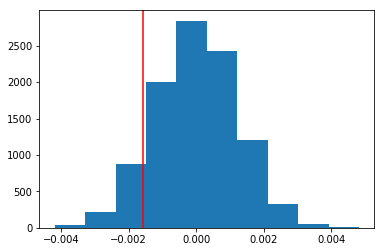

```python
obs = df2.query('group == "treatment"').converted.mean() - df2.query('group == "control"').converted.mean()
plt.hist(p_diffs)
plt.axvline(obs, color = 'r');
```

p值

```python
p_diffs = np.array(p_diffs)
(p_diffs > obs).mean()
```

```
0.9019
```

p 值大于 0.05，不能拒绝零假设，也就是新旧页面的转化率不能证明有区别。

## 下面采用中心极限定理模拟零假设

假定旧的页面效果更好，零假设和备择假设是:

**$$H0:p_{new} - p_{old} <= 0$$** **$$H1:p_{new} - p_{old} > 0$$**

```python
diffs = []
for _ in range(2000):
    sample = df2.sample(df2.shape[0], replace=True)
    p_new = sample.query('group == "treatment"').converted.mean()
    p_old = sample.query('group == "control"').converted.mean()
    diffs.append(p_new - p_old)
```

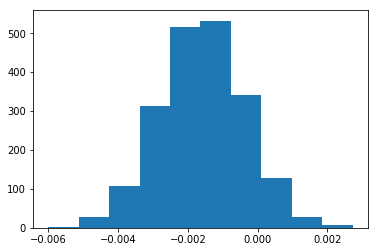

```python
plt.hist(diffs);
```

2000 个样本的转化率（也就是均值）差的分布是正态分布，该样本及更极端情况出现的概率为 p 值

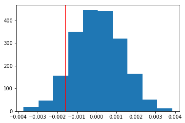

```python
diffs = np.array(diffs)
null_vals = np.random.normal(0, diffs.std(), diffs.size)
plt.hist(null_vals)
plt.axvline(obs, color = 'r');
```

```python
(null_vals > obs).mean()
```

```
0.9085
```

**结果相同，p 值大于 0.05，不能拒绝零假设。**

内置程序 （built-in）来实现类似的结果

```python
import statsmodels.api as sm

convert_old = df2.query('group == "control"').converted.sum()
convert_new = df2.query('group == "treatment"').converted.sum()
n_old = df2.query('group == "control"').shape[0]
n_new = df2.query('group == "treatment"').shape[0]
```

z 分数和 p 值

```python
z_score, p_val = sm.stats.proportions_ztest(
    [convert_old, convert_new], [n_old, n_new], alternative='smaller')
z_score, p_val
```

```
(1.3109241984234394, 0.9050583127590245)
```

**结论一样，p 值大于 0.05，所以不能认为新旧页面有区别。**

### III - 逻辑回归

目标是使用 **statsmodels** 来拟合回归模型，以查看用户收到的不同页面是否存在显著的转化差异。

```python
df2['d'] = 1
df2[['con', 'ab_page']] = pd.get_dummies(df2.group)
df2 = df2.drop('con', axis=1)
df2.head()
```

|  | user_id | timestamp | group | landing_page | converted | d | ab_page |
| --- | --- | --- | --- | --- | --- | --- | --- |
| 0 | 851104 | 2017-01-21 22:11:48.556739 | control | old_page | 0 | 1 | 0 |
| 1 | 804228 | 2017-01-12 08:01:45.159739 | control | old_page | 0 | 1 | 0 |
| 2 | 661590 | 2017-01-11 16:55:06.154213 | treatment | new_page | 0 | 1 | 1 |
| 3 | 853541 | 2017-01-08 18:28:03.143765 | treatment | new_page | 0 | 1 | 1 |
| 4 | 864975 | 2017-01-21 01:52:26.210827 | control | old_page | 1 | 1 | 0 |

```python
df2.head()
```

|  | user_id | timestamp | group | landing_page | converted | d | ab_page |
| --- | --- | --- | --- | --- | --- | --- | --- |
| 0 | 851104 | 2017-01-21 22:11:48.556739 | control | old_page | 0 | 1 | 0 |
| 1 | 804228 | 2017-01-12 08:01:45.159739 | control | old_page | 0 | 1 | 0 |
| 2 | 661590 | 2017-01-11 16:55:06.154213 | treatment | new_page | 0 | 1 | 1 |
| 3 | 853541 | 2017-01-08 18:28:03.143765 | treatment | new_page | 0 | 1 | 1 |
| 4 | 864975 | 2017-01-21 01:52:26.210827 | control | old_page | 1 | 1 | 0 |

```python
lm = sm.Logit(df2['converted'], df2[['d', 'ab_page']])
```

```python
lm.fit().summary()
```

```
Optimization terminated successfully.
         Current function value: 0.366118
         Iterations 6
```

Logit Regression Results

| Dep. Variable: | converted | No. Observations: | 290584 |
| --- | --- | --- | --- |
| Model: | Logit | Df Residuals: | 290582 |
| Method: | MLE | Df Model: | 1 |
| Date: | Fri, 03 May 2019 | Pseudo R-squ.: | 8.077e-06 |
| Time: | 14:34:55 | Log-Likelihood: | -1.0639e+05 |
| converged: | True | LL-Null: | -1.0639e+05 |
|  |  | LLR p-value: | 0.1899 |

|  | coef | std err | z | P>\|z\| | [0.025 | 0.975] |
| --- | --- | --- | --- | --- | --- | --- |
| d | -1.9888 | 0.008 | -246.669 | 0.000 | -2.005 | -1.973 |
| ab_page | -0.0150 | 0.011 | -1.311 | 0.190 | -0.037 | 0.007 |

**p 值为 0.19，大于0.05，与II中发现的结果相似，都是不能证明新旧页面有差别。但 II 中为单尾假设，逻辑回归模型假设为双尾假设，所以 p 值不同，逻辑回归假设为：** **$$H0:p_{new} - p_{old} = 0$$** **$$H1:p_{new} - p_{old} ！= 0$$**

下面添加国家因素，检验是否影响新旧页面转化率

```python
df3 = pd.read_csv('countries.csv')
print(df3.isnull().sum().sum(), df3.duplicated().sum(), df3.shape)
df3.country.value_counts()
```

```
0 0 (290584, 2)
```

```
US    203619
UK     72466
CA     14499
Name: country, dtype: int64
```

```python
df3 = df2.set_index('user_id').join(df3.set_index('user_id'))
df3[['CA', 'UK', 'US']] = pd.get_dummies(df3['country'])
df3 = df3.drop('US', axis=1)
```

```python
lm = sm.Logit(df3['converted'], df3[['d', 'CA', 'UK']])
lm.fit().summary()
```

```
Optimization terminated successfully.
         Current function value: 0.366116
         Iterations 6
```

Logit Regression Results

| Dep. Variable: | converted | No. Observations: | 290584 |
| --- | --- | --- | --- |
| Model: | Logit | Df Residuals: | 290581 |
| Method: | MLE | Df Model: | 2 |
| Date: | Fri, 03 May 2019 | Pseudo R-squ.: | 1.521e-05 |
| Time: | 14:35:13 | Log-Likelihood: | -1.0639e+05 |
| converged: | True | LL-Null: | -1.0639e+05 |
|  |  | LLR p-value: | 0.1984 |

|  | coef | std err | z | P>\|z\| | [0.025 | 0.975] |
| --- | --- | --- | --- | --- | --- | --- |
| d | -1.9967 | 0.007 | -292.314 | 0.000 | -2.010 | -1.983 |
| CA | -0.0408 | 0.027 | -1.518 | 0.129 | -0.093 | 0.012 |
| UK | 0.0099 | 0.013 | 0.746 | 0.456 | -0.016 | 0.036 |

**p 值大于 0.05，不能证明国家对转化有影响。**

查看页面与国家/地区之间的相互作用，测试其是否会对转化产生重大影响

```python
df3['new_CA'] = df3['ab_page'] * df3['CA']
df3['new_UK'] = df3['ab_page'] * df3['UK']
lm = sm.Logit(df3['converted'], df3[['d', 'ab_page', 'CA', 'new_CA', 'UK', 'new_UK']])
lm.fit().summary()
```

```
Optimization terminated successfully.
         Current function value: 0.366109
         Iterations 6
```

Logit Regression Results

| Dep. Variable: | converted | No. Observations: | 290584 |
| --- | --- | --- | --- |
| Model: | Logit | Df Residuals: | 290578 |
| Method: | MLE | Df Model: | 5 |
| Date: | Fri, 03 May 2019 | Pseudo R-squ.: | 3.482e-05 |
| Time: | 14:35:57 | Log-Likelihood: | -1.0639e+05 |
| converged: | True | LL-Null: | -1.0639e+05 |
|  |  | LLR p-value: | 0.1920 |

|  | coef | std err | z | P>\|z\| | [0.025 | 0.975] |
| --- | --- | --- | --- | --- | --- | --- |
| d | -1.9865 | 0.010 | -206.344 | 0.000 | -2.005 | -1.968 |
| ab_page | -0.0206 | 0.014 | -1.505 | 0.132 | -0.047 | 0.006 |
| CA | -0.0175 | 0.038 | -0.465 | 0.642 | -0.091 | 0.056 |
| new_CA | -0.0469 | 0.054 | -0.872 | 0.383 | -0.152 | 0.059 |
| UK | -0.0057 | 0.019 | -0.306 | 0.760 | -0.043 | 0.031 |
| new_UK | 0.0314 | 0.027 | 1.181 | 0.238 | -0.021 | 0.084 |

**p 值都大于 0.05，城市的新页面的转化率也没有显著差异。**

## 总结

新旧页面并无显著差异，可能需要继续监控，或者隔一段时间监控一次，此次没有考虑时间因素，可能和时间因素有关。